# My_Cars4U_Project-Final

#### Background & Context

There is a huge demand for used cars in the Indian Market today. As sales of new cars have slowed down in the recent past, the pre-owned car market has continued to grow over the past years and is larger than the new car market now. Cars4U is a budding tech start-up that aims to find footholes in this market.

In 2018-19, while new car sales were recorded at 3.6 million units, around 4 million second-hand cars were bought and sold. There is a slowdown in new car sales and that could mean that the demand is shifting towards the pre-owned market. In fact, some car sellers replace their old cars with pre-owned cars instead of buying new ones. Unlike new cars, where price and supply are fairly deterministic and managed by OEMs (Original Equipment Manufacturer / except for dealership level discounts which come into play only in the last stage of the customer journey), used cars are very different beasts with huge uncertainty in both pricing and supply. Keeping this in mind, the pricing scheme of these used cars becomes important in order to grow in the market.

As a senior data scientist at Cars4U, you have to come up with a pricing model that can effectively predict the price of used cars and can help the business in devising profitable strategies using differential pricing. For example, if the business knows the market price, it will never sell anything below it.

#### Objective

```
Explore and visualize the dataset.
Build a linear regression model to predict the prices of used cars.
Generate a set of insights and recommendations that will help the business.
```

#### Data Dictionary

```
S.No. : Serial Number
Name : Name of the car which includes Brand name and Model name
Location : The location in which the car is being sold or is available for purchase Cities
Year : Manufacturing year of the car
Kilometers_driven : The total kilometers driven in the car by the previous owner(s) in KM.
Fuel_Type : The type of fuel used by the car. (Petrol, Diesel, Electric, CNG, LPG)
Transmission : The type of transmission used by the car. (Automatic / Manual)
Owner : Type of ownership
Mileage : The standard mileage offered by the car company in kmpl or km/kg
Engine : The displacement volume of the engine in CC.
Power : The maximum power of the engine in bhp.
Seats : The number of seats in the car.
New_Price : The price of a new car of the same model in INR Lakhs.(1 Lakh = 100, 000)
Price : The price of the used car in INR Lakhs (1 Lakh = 100, 000)
```

#### Import the applicable libraries

```python
# Import necessary libraries.
import warnings
warnings.filterwarnings("ignore")

import numpy as np
import pandas as pd
import matplotlib.pyplot as plt
import seaborn as sns
import statsmodels.api as sm

# To enable plotting graphs in Jupyter notebook
%matplotlib inline
pd.set_option('display.float_format', lambda x: '%.3f' % x) # to display numbers in digits
```

### Reading the Dataset

```python
my_data = pd.read_csv('used_cars_data.csv')
c_d= my_data.copy()
```

### Reading the first 5 Entries of the dataset

```python
c_d.head()
```

|  | S.No. | Name | Location | Year | Kilometers_Driven | Fuel_Type | Transmission | Owner_Type | Mileage | Engine | Power | Seats | New_Price | Price |
| --- | --- | --- | --- | --- | --- | --- | --- | --- | --- | --- | --- | --- | --- | --- |
| 0 | 0 | Maruti Wagon R LXI CNG | Mumbai | 2010 | 72000 | CNG | Manual | First | 26.6 km/kg | 998 CC | 58.16 bhp | 5.000 | NaN | 1.750 |
| 1 | 1 | Hyundai Creta 1.6 CRDi SX Option | Pune | 2015 | 41000 | Diesel | Manual | First | 19.67 kmpl | 1582 CC | 126.2 bhp | 5.000 | NaN | 12.500 |
| 2 | 2 | Honda Jazz V | Chennai | 2011 | 46000 | Petrol | Manual | First | 18.2 kmpl | 1199 CC | 88.7 bhp | 5.000 | 8.61 Lakh | 4.500 |
| 3 | 3 | Maruti Ertiga VDI | Chennai | 2012 | 87000 | Diesel | Manual | First | 20.77 kmpl | 1248 CC | 88.76 bhp | 7.000 | NaN | 6.000 |
| 4 | 4 | Audi A4 New 2.0 TDI Multitronic | Coimbatore | 2013 | 40670 | Diesel | Automatic | Second | 15.2 kmpl | 1968 CC | 140.8 bhp | 5.000 | NaN | 17.740 |

### Reading the last 5 Entries of the dataset

```python
c_d.tail()
```

|  | S.No. | Name | Location | Year | Kilometers_Driven | Fuel_Type | Transmission | Owner_Type | Mileage | Engine | Power | Seats | New_Price | Price |
| --- | --- | --- | --- | --- | --- | --- | --- | --- | --- | --- | --- | --- | --- | --- |
| 7248 | 7248 | Volkswagen Vento Diesel Trendline | Hyderabad | 2011 | 89411 | Diesel | Manual | First | 20.54 kmpl | 1598 CC | 103.6 bhp | 5.000 | NaN | nan |
| 7249 | 7249 | Volkswagen Polo GT TSI | Mumbai | 2015 | 59000 | Petrol | Automatic | First | 17.21 kmpl | 1197 CC | 103.6 bhp | 5.000 | NaN | nan |
| 7250 | 7250 | Nissan Micra Diesel XV | Kolkata | 2012 | 28000 | Diesel | Manual | First | 23.08 kmpl | 1461 CC | 63.1 bhp | 5.000 | NaN | nan |
| 7251 | 7251 | Volkswagen Polo GT TSI | Pune | 2013 | 52262 | Petrol | Automatic | Third | 17.2 kmpl | 1197 CC | 103.6 bhp | 5.000 | NaN | nan |
| 7252 | 7252 | Mercedes-Benz E-Class 2009-2013 E 220 CDI Avan... | Kochi | 2014 | 72443 | Diesel | Automatic | First | 10.0 kmpl | 2148 CC | 170 bhp | 5.000 | NaN | nan |

```python
c_d.sample(25) # To study for data consistency and pick a pattern in a Random number of samples
```

|  | S.No. | Name | Location | Year | Kilometers_Driven | Fuel_Type | Transmission | Owner_Type | Mileage | Engine | Power | Seats | New_Price | Price |
| --- | --- | --- | --- | --- | --- | --- | --- | --- | --- | --- | --- | --- | --- | --- |
| 5808 | 5808 | Maruti Celerio VXI AMT | Kolkata | 2016 | 30000 | Petrol | Automatic | First | 23.1 kmpl | 998 CC | 67.04 bhp | 5.000 | 5.77 Lakh | 3.800 |
| 7123 | 7123 | Renault Duster 85PS Diesel RxL Optional | Delhi | 2013 | 64000 | Diesel | Manual | First | 20.46 kmpl | 1461 CC | 83.8 bhp | 5.000 | NaN | nan |
| 4765 | 4765 | Maruti Ertiga VXI | Mumbai | 2014 | 69192 | Petrol | Manual | First | 16.02 kmpl | 1373 CC | 93.7 bhp | 7.000 | NaN | 6.250 |
| 2917 | 2917 | Maruti Ignis 1.2 AMT Alpha | Coimbatore | 2019 | 3906 | Petrol | Automatic | First | 20.89 kmpl | 1197 CC | 81.80 bhp | 5.000 | 7.96 Lakh | 7.360 |
| 2088 | 2088 | Honda City i-VTEC V | Delhi | 2011 | 67031 | Petrol | Manual | First | 17.4 kmpl | 1497 CC | 117.3 bhp | 5.000 | 11.85 Lakh | 4.000 |
| 5619 | 5619 | Hyundai i20 1.4 Asta Optional With Sunroof | Bangalore | 2010 | 77332 | Diesel | Manual | Second | 23.0 kmpl | 1396 CC | 90 bhp | 5.000 | NaN | 3.650 |
| 2777 | 2777 | Honda City 1.5 V MT Exclusive | Pune | 2012 | 45496 | Petrol | Manual | First | 17.0 kmpl | 1497 CC | 118 bhp | 5.000 | NaN | 4.750 |
| 5796 | 5796 | Volkswagen Polo 1.2 MPI Trendline | Delhi | 2016 | 27000 | Petrol | Manual | First | 18.78 kmpl | 999 CC | 74 bhp | 5.000 | NaN | 4.500 |
| 6189 | 6189 | Toyota Etios V | Mumbai | 2012 | 59503 | Petrol | Manual | First | 16.78 kmpl | 1496 CC | 88.73 bhp | 5.000 | NaN | nan |
| 737 | 737 | Hyundai Accent GLS | Bangalore | 2008 | 72000 | Petrol | Manual | Second | 13.2 kmpl | 1495 CC | 94 bhp | 5.000 | NaN | 2.000 |
| 6092 | 6092 | Tata Tiago AMT 1.2 Revotron XTA | Mumbai | 2017 | 14000 | Petrol | Automatic | First | 23.84 kmpl | 1199 CC | 84 bhp | 5.000 | 6.3 Lakh | nan |
| 2169 | 2169 | Mahindra Scorpio SLE BSIII | Pune | 2010 | 96813 | Diesel | Manual | Second | 12.05 kmpl | 2179 CC | 120 bhp | 8.000 | NaN | 5.500 |
| 1709 | 1709 | Maruti Swift VXI Optional | Kochi | 2017 | 37124 | Petrol | Manual | First | 20.4 kmpl | 1197 CC | 81.80 bhp | 5.000 | NaN | 5.440 |
| 4752 | 4752 | Ford Figo Diesel EXI | Delhi | 2013 | 54000 | Diesel | Manual | First | 20.0 kmpl | 1399 CC | 68.05 bhp | 5.000 | NaN | 2.550 |
| 2172 | 2172 | Mahindra XUV500 W6 2WD | Coimbatore | 2016 | 67995 | Diesel | Manual | First | 16.0 kmpl | 2179 CC | 140 bhp | 7.000 | NaN | 11.730 |
| 4640 | 4640 | Honda Amaze VX i-DTEC | Delhi | 2013 | 75348 | Diesel | Manual | First | 25.8 kmpl | 1498 CC | 98.6 bhp | 5.000 | NaN | 3.750 |
| 2180 | 2180 | Nissan Terrano XL 110 PS | Mumbai | 2014 | 50000 | Diesel | Manual | First | 19.01 kmpl | 1461 CC | 108.5 bhp | 5.000 | NaN | 6.500 |
| 3963 | 3963 | Mitsubishi Lancer 1.5 SFXi | Chennai | 2001 | 104000 | Petrol | Manual | Third | 13.7 kmpl | 1468 CC | 85.8 bhp | 5.000 | NaN | 1.000 |
| 4589 | 4589 | Honda City i-VTEC S | Jaipur | 2010 | 48689 | Petrol | Manual | First | 17.4 kmpl | 1497 CC | 117.3 bhp | 5.000 | NaN | 3.870 |
| 544 | 544 | Mercedes-Benz New C-Class Progressive C 200 | Kochi | 2019 | 13190 | Petrol | Automatic | First | 0.0 kmpl | 1950 CC | 181.43 bhp | 5.000 | 49.49 Lakh | 38.990 |
| 7049 | 7049 | Maruti Alto LXi BSIII | Hyderabad | 2011 | 63528 | Petrol | Manual | First | 19.7 kmpl | 796 CC | 46.3 bhp | 5.000 | NaN | nan |
| 3044 | 3044 | Hyundai Santro Xing GL | Kolkata | 2009 | 60170 | Petrol | Manual | First | 0.0 kmpl | 1086 CC | 62 bhp | 5.000 | NaN | 1.150 |
| 3251 | 3251 | Hyundai Verna 1.6 SX VTVT | Chennai | 2016 | 51000 | Petrol | Manual | First | 17.01 kmpl | 1591 CC | 121.3 bhp | 5.000 | NaN | 6.500 |
| 7214 | 7214 | Hyundai i20 Active 1.4 SX | Delhi | 2017 | 14301 | Diesel | Manual | First | 21.19 kmpl | 1396 CC | 88.73 bhp | 5.000 | NaN | nan |
| 5904 | 5904 | Ford Ecosport 1.5 DV5 MT Titanium | Mumbai | 2015 | 44000 | Diesel | Manual | First | 22.7 kmpl | 1498 CC | 89.84 bhp | 5.000 | NaN | 7.350 |

#### Observation

###### The dataset indicates a messy structure

###### Mileage,Engine and Power have units and New_Price is a currency column

###### The Power column has null bhp values as can be seen. This will equally be treated prior to further analysis

###### These observations will require fixing as we proceed before Exploratory Data Analysis

### Checking the shape of the Dataset

```python
c_d.shape
```

```
(7253, 14)
```

##### The dataset has 7253 Rows and 14 Columns

### Identifying the Columns of the dataset

```python
c_d.columns # this indicates the columns of the dataset
```

```
Index(['S.No.', 'Name', 'Location', 'Year', 'Kilometers_Driven', 'Fuel_Type',
       'Transmission', 'Owner_Type', 'Mileage', 'Engine', 'Power', 'Seats',
       'New_Price', 'Price'],
      dtype='object')
```

### Checking the Data Types

```python
c_d.info()
```

```
<class 'pandas.core.frame.DataFrame'>
RangeIndex: 7253 entries, 0 to 7252
Data columns (total 14 columns):
 #   Column             Non-Null Count  Dtype
---  ------             --------------  -----
 0   S.No.              7253 non-null   int64
 1   Name               7253 non-null   object
 2   Location           7253 non-null   object
 3   Year               7253 non-null   int64
 4   Kilometers_Driven  7253 non-null   int64
 5   Fuel_Type          7253 non-null   object
 6   Transmission       7253 non-null   object
 7   Owner_Type         7253 non-null   object
 8   Mileage            7251 non-null   object
 9   Engine             7207 non-null   object
 10  Power              7207 non-null   object
 11  Seats              7200 non-null   float64
 12  New_Price          1006 non-null   object
 13  Price              6019 non-null   float64
dtypes: float64(2), int64(3), object(9)
memory usage: 793.4+ KB
```

### Fix Data Types

1. Of the 14 Variables, 3 are Integers and 2 of Float data type which are valid data types except for 9 remaining variables of object string data type.
2. Name, Location,Fuel_Type, Transmission and Owner_Type are of object type. These will be converted to category data type.
3. Year will also be converted to categorical variable since we cannot say a year is greater than the other.
4. Mileage,Engine, Power and New_Price are numerical in value but are strings. We would need to strip them of units and convert them to real numerical values for further analysis

Note that converting "objects" to "category" reduces the data space required to store the dataframe

```python
# Converting data types
c_d["Name"]= c_d["Name"].astype("category")
c_d["Location"]= c_d["Location"].astype("category")
c_d["Fuel_Type"]= c_d["Fuel_Type"].astype("category")
c_d["Transmission"]= c_d["Transmission"].astype("category")
c_d["Owner_Type"]= c_d["Owner_Type"].astype("category")
c_d["Year"]= c_d["Year"].astype("category")
```

### Reconfirming the data types

```python
c_d.info()
```

```
<class 'pandas.core.frame.DataFrame'>
RangeIndex: 7253 entries, 0 to 7252
Data columns (total 14 columns):
 #   Column             Non-Null Count  Dtype
---  ------             --------------  -----
 0   S.No.              7253 non-null   int64
 1   Name               7253 non-null   category
 2   Location           7253 non-null   category
 3   Year               7253 non-null   category
 4   Kilometers_Driven  7253 non-null   int64
 5   Fuel_Type          7253 non-null   category
 6   Transmission       7253 non-null   category
 7   Owner_Type         7253 non-null   category
 8   Mileage            7251 non-null   object
 9   Engine             7207 non-null   object
 10  Power              7207 non-null   object
 11  Seats              7200 non-null   float64
 12  New_Price          1006 non-null   object
 13  Price              6019 non-null   float64
dtypes: category(6), float64(2), int64(2), object(4)
memory usage: 600.6+ KB
```

### All object string data types have been converted to the category data type except Mileage,Engine,Power and New_Price which we will be converting to numericals

#### Also note the memory usage drop from 793.4 kb to 600.6kb

```python
c_d.isna().sum().sort_values(ascending=False)### To confirm if there is any missing values in the dataset
```

```
New_Price            6247
Price                1234
Seats                  53
Power                  46
Engine                 46
Mileage                 2
Owner_Type              0
Transmission            0
Fuel_Type               0
Kilometers_Driven       0
Year                    0
Location                0
Name                    0
S.No.                   0
dtype: int64
```

##### Observation

1. New_Price has the highest number of missing values which conveys the possibility of an incomplete/erroneous data .It will be dropped for a cleaner analysis
2. S.No will also be dropped from the dataset as it affects nothing
3. Price comes next and finally Seats,Mileage,Engine and Power
4. We will start by fixing the Missingness per column and the null values.

### Dropping the S.No and the New_Price Columns

```python
c_d.drop(['S.No.','New_Price'], axis=1, inplace=True)
c_d.head()
```

|  | Name | Location | Year | Kilometers_Driven | Fuel_Type | Transmission | Owner_Type | Mileage | Engine | Power | Seats | Price |
| --- | --- | --- | --- | --- | --- | --- | --- | --- | --- | --- | --- | --- |
| 0 | Maruti Wagon R LXI CNG | Mumbai | 2010 | 72000 | CNG | Manual | First | 26.6 km/kg | 998 CC | 58.16 bhp | 5.000 | 1.750 |
| 1 | Hyundai Creta 1.6 CRDi SX Option | Pune | 2015 | 41000 | Diesel | Manual | First | 19.67 kmpl | 1582 CC | 126.2 bhp | 5.000 | 12.500 |
| 2 | Honda Jazz V | Chennai | 2011 | 46000 | Petrol | Manual | First | 18.2 kmpl | 1199 CC | 88.7 bhp | 5.000 | 4.500 |
| 3 | Maruti Ertiga VDI | Chennai | 2012 | 87000 | Diesel | Manual | First | 20.77 kmpl | 1248 CC | 88.76 bhp | 7.000 | 6.000 |
| 4 | Audi A4 New 2.0 TDI Multitronic | Coimbatore | 2013 | 40670 | Diesel | Automatic | Second | 15.2 kmpl | 1968 CC | 140.8 bhp | 5.000 | 17.740 |

```python
c_d.shape
```

```
(7253, 12)
```

### Fixing the Columns for Mileage, Engine and Power

###### Power has 'null bhp' values which we need to set to '0'

```python
# Setting the 'null bhp' values to '0' for Power
c_d['Power'] = c_d['Power'].replace('null bhp','0')
```

### Mileage Column

```python
mile_col = []
for colname in c_d.columns[c_d.dtypes == 'object']:  # only considers string column
    if c_d[colname].str.endswith('km/kg').any():  # using `.str` so I can use an element-wise string method
        mile_col.append(colname)
print(mile_col)
```

```
['Mileage']
```

```python
def mile_to_num(mile_val):
    """This function takes in a string representing Mileage in 'km/kg' or 'kmpl'
    and converts it to a number.
    If the input is already numeric, which probably means it's NaN,
    this function just returns np.nan."""
    if isinstance(mile_val, str):  # checks if `mile_val` is a string
        multiplier = 1  # handles the km/kg and kmpl units
        if mile_val.endswith('km/kg'):
            multiplier = 1
        elif mile_val.endswith('kmpl'):
            multiplier = 1
            return float(mile_val.replace('km/kg', '').replace('kmpl', '')) * multiplier
    else:  # this happens when the current mileage is np.nan
        return np.nan

for colname in mile_col:
    c_d[colname] = c_d[colname].apply(mile_to_num)

c_d[mile_col].head()
```

|  | Mileage |
| --- | --- |
| 0 | nan |
| 1 | 19.670 |
| 2 | 18.200 |
| 3 | 20.770 |
| 4 | 15.200 |

### Power and Engine Columns

```python
PE_col = []
for colname in c_d.columns[c_d.dtypes == 'object']:  # only considers string column
    if c_d[colname].str.endswith('bhp','CC').any():  # using `.str` so I can use an element-wise string method
        PE_col.append(colname)
print(PE_col)
```

```
['Engine', 'Power']
```

```python
def pe_to_num(pe_val):
    """This function takes in a string representing enteries for Power or Engine  in 'bhp' or 'CC'
    and converts it to a number.
    If the input is already numeric, which probably means it's NaN,
    this function just returns np.nan."""
    if isinstance(pe_val, str):  # checks if `PE_val` is a string
        multiplier = 1  # handles the bhp and CC units
        if pe_val.endswith('bhp'):
            multiplier = 1
        elif pe_val.endswith('CC'):
            multiplier = 1
        return float(pe_val.replace('bhp', '').replace('CC', '')) * multiplier
    else:  # this happens when the current value is np.nan
        return np.nan

for colname in PE_col:
    c_d[colname] = c_d[colname].apply(pe_to_num)

c_d[PE_col].head()
```

|  | Engine | Power |
| --- | --- | --- |
| 0 | 998.000 | 58.160 |
| 1 | 1582.000 | 126.200 |
| 2 | 1199.000 | 88.700 |
| 3 | 1248.000 | 88.760 |
| 4 | 1968.000 | 140.800 |

```python
### Checking Consistency
c_d.head(10)
```

|  | Name | Location | Year | Kilometers_Driven | Fuel_Type | Transmission | Owner_Type | Mileage | Engine | Power | Seats | Price |
| --- | --- | --- | --- | --- | --- | --- | --- | --- | --- | --- | --- | --- |
| 0 | Maruti Wagon R LXI CNG | Mumbai | 2010 | 72000 | CNG | Manual | First | nan | 998.000 | 58.160 | 5.000 | 1.750 |
| 1 | Hyundai Creta 1.6 CRDi SX Option | Pune | 2015 | 41000 | Diesel | Manual | First | 19.670 | 1582.000 | 126.200 | 5.000 | 12.500 |
| 2 | Honda Jazz V | Chennai | 2011 | 46000 | Petrol | Manual | First | 18.200 | 1199.000 | 88.700 | 5.000 | 4.500 |
| 3 | Maruti Ertiga VDI | Chennai | 2012 | 87000 | Diesel | Manual | First | 20.770 | 1248.000 | 88.760 | 7.000 | 6.000 |
| 4 | Audi A4 New 2.0 TDI Multitronic | Coimbatore | 2013 | 40670 | Diesel | Automatic | Second | 15.200 | 1968.000 | 140.800 | 5.000 | 17.740 |
| 5 | Hyundai EON LPG Era Plus Option | Hyderabad | 2012 | 75000 | LPG | Manual | First | nan | 814.000 | 55.200 | 5.000 | 2.350 |
| 6 | Nissan Micra Diesel XV | Jaipur | 2013 | 86999 | Diesel | Manual | First | 23.080 | 1461.000 | 63.100 | 5.000 | 3.500 |
| 7 | Toyota Innova Crysta 2.8 GX AT 8S | Mumbai | 2016 | 36000 | Diesel | Automatic | First | 11.360 | 2755.000 | 171.500 | 8.000 | 17.500 |
| 8 | Volkswagen Vento Diesel Comfortline | Pune | 2013 | 64430 | Diesel | Manual | First | 20.540 | 1598.000 | 103.600 | 5.000 | 5.200 |
| 9 | Tata Indica Vista Quadrajet LS | Chennai | 2012 | 65932 | Diesel | Manual | Second | 22.300 | 1248.000 | 74.000 | 5.000 | 1.950 |

```python
### Taking into consideration the rate of 1 Lakh = 100000 INR and applying to the Price column
c_d['Price'] = c_d.Price.apply(lambda x: x*100000)# price in INR
```

```python
c_d.head()
```

|  | Name | Location | Year | Kilometers_Driven | Fuel_Type | Transmission | Owner_Type | Mileage | Engine | Power | Seats | Price |
| --- | --- | --- | --- | --- | --- | --- | --- | --- | --- | --- | --- | --- |
| 0 | Maruti Wagon R LXI CNG | Mumbai | 2010 | 72000 | CNG | Manual | First | nan | 998.000 | 58.160 | 5.000 | 175000.000 |
| 1 | Hyundai Creta 1.6 CRDi SX Option | Pune | 2015 | 41000 | Diesel | Manual | First | 19.670 | 1582.000 | 126.200 | 5.000 | 1250000.000 |
| 2 | Honda Jazz V | Chennai | 2011 | 46000 | Petrol | Manual | First | 18.200 | 1199.000 | 88.700 | 5.000 | 450000.000 |
| 3 | Maruti Ertiga VDI | Chennai | 2012 | 87000 | Diesel | Manual | First | 20.770 | 1248.000 | 88.760 | 7.000 | 600000.000 |
| 4 | Audi A4 New 2.0 TDI Multitronic | Coimbatore | 2013 | 40670 | Diesel | Automatic | Second | 15.200 | 1968.000 | 140.800 | 5.000 | 1774000.000 |

```python
#### Checking data types for consistency
c_d.dtypes
```

```
Name                 category
Location             category
Year                 category
Kilometers_Driven       int64
Fuel_Type            category
Transmission         category
Owner_Type           category
Mileage               float64
Engine                float64
Power                 float64
Seats                 float64
Price                 float64
dtype: object
```

##### Now we can proceed to missingness.

1. 16% of the missing values in Price can be filled with the median instead of removing them entirely so our analysis and model integrity is well secure
2. We will play safe by filling all missing values of the other numericals with the medians

### Fixing Missing Values

```python
# Checking the Number of unique values accross columns
c_d.nunique()
```

```
Name                 2041
Location               11
Year                   23
Kilometers_Driven    3660
Fuel_Type               5
Transmission            2
Owner_Type              4
Mileage               425
Engine                150
Power                 384
Seats                   9
Price                1373
dtype: int64
```

#### Observation

1. Sample data ws drawn from 11 different locations
2. There are 2 Transmission types,5 Fuel Types and 4 Owner Types

```python
# Replacing missing values in every column with its medain
medianFiller = lambda x: x.fillna(x.median())
num_cols = c_d.select_dtypes(include=np.number).columns.tolist()
c_d[num_cols] = c_d[num_cols].apply(medianFiller,axis=0)
```

```python
cd_reg = c_d.copy() # Let us make a copy just in case we need to readjust and reprioritize the columns prior to modeling
```

### Confirming the the correction of Missingness

```python
c_d.isna().sum()
```

```
Name                 0
Location             0
Year                 0
Kilometers_Driven    0
Fuel_Type            0
Transmission         0
Owner_Type           0
Mileage              0
Engine               0
Power                0
Seats                0
Price                0
dtype: int64
```

#### Observation

All Missng values have been treated.

## Statistical Summary of the Cleaned Dataset

```python
# This  also gives us the 5 point Summary of the Dataframe
c_d.describe().T
```

|  | count | mean | std | min | 25% | 50% | 75% | max |
| --- | --- | --- | --- | --- | --- | --- | --- | --- |
| Kilometers_Driven | 7253.000 | 58699.063 | 84427.721 | 171.000 | 34000.000 | 53416.000 | 73000.000 | 6500000.000 |
| Mileage | 7253.000 | 18.078 | 4.469 | 0.000 | 15.260 | 18.150 | 20.920 | 28.400 |
| Engine | 7253.000 | 1615.790 | 593.475 | 72.000 | 1198.000 | 1493.000 | 1968.000 | 5998.000 |
| Power | 7253.000 | 110.626 | 54.927 | 0.000 | 74.000 | 91.720 | 138.030 | 616.000 |
| Seats | 7253.000 | 5.278 | 0.809 | 0.000 | 5.000 | 5.000 | 5.000 | 10.000 |
| Price | 7253.000 | 882623.466 | 1029331.324 | 44000.000 | 385000.000 | 564000.000 | 840000.000 | 16000000.000 |

#### Observation

###### Note that there are still Zero enteries in the Mileage, Power and Seats columns

###### This has to be treated to give us an accurate statistical Summary

```python
# Treating Zero enteries in Mileage, Power and Seats
c_d = c_d[c_d['Mileage'] !=0]
c_d = c_d[c_d['Power'] !=0]
c_d = c_d[c_d['Seats'] !=0]
c_d.describe().T
```

|  | count | mean | std | min | 25% | 50% | 75% | max |
| --- | --- | --- | --- | --- | --- | --- | --- | --- |
| Kilometers_Driven | 7076.000 | 58327.386 | 85231.228 | 171.000 | 33548.500 | 53000.000 | 72669.000 | 6500000.000 |
| Mileage | 7076.000 | 18.294 | 4.062 | 6.400 | 15.300 | 18.190 | 21.100 | 28.400 |
| Engine | 7076.000 | 1617.519 | 592.105 | 72.000 | 1198.000 | 1493.000 | 1968.000 | 5998.000 |
| Power | 7076.000 | 112.560 | 53.336 | 34.200 | 75.000 | 93.700 | 138.043 | 616.000 |
| Seats | 7076.000 | 5.285 | 0.810 | 2.000 | 5.000 | 5.000 | 5.000 | 10.000 |
| Price | 7076.000 | 886664.782 | 1027920.955 | 44000.000 | 390000.000 | 564000.000 | 850000.000 | 16000000.000 |

#### Observation

1. The Mean > Median for Kilometer driven and a high prevalence of outliers.It is right skewed
2. The Mean > Median for Mileage, hence Right skewed distribution.Presence of outliers
3. The Mean > Median for both Engine and Power with possible presence of outliers considering the range in both cases
4. The Mean > Median for Price. Highly skewed to the right with an obvious presence of unusual outliers

```python
#summary of non-numeric columns
c_d.describe(include=["category"])
```

|  | Name | Location | Year | Fuel_Type | Transmission | Owner_Type |
| --- | --- | --- | --- | --- | --- | --- |
| count | 7076 | 7076 | 7076 | 7076 | 7076 | 7076 |
| unique | 1975 | 11 | 22 | 5 | 2 | 4 |
| top | Mahindra XUV500 W8 2WD | Mumbai | 2015 | Diesel | Manual | First |
| freq | 55 | 934 | 925 | 3771 | 5064 | 5834 |

#### Observation

1. The Mahindra XUV500 W8 was the most available used car model with 55 units for sale
2. The city of Mumbai returned 934 as the highest units of used car available for sale in India
3. The highest number (925 units) of car models manufactured in the year 2015 enjoyed the highest patronage
4. Diesel Fuel Type cars returned the highest turnover in number of car units for sale at 3771
5. Manual Transmission vehicles have the highest number of cars availble by Transmission type with 5064 units
6. The volume of First Owner-Type topped with 5834

### Checking for Measures of Dispersion (IQR,Range,Standard and Mean Absolute Deviation)

```python
c_d.quantile(0.75) - c_d.quantile(0.25) # Inter Quartile Range (IQR)
```

```
Kilometers_Driven    39120.500
Mileage                  5.800
Engine                 770.000
Power                   63.043
Seats                    0.000
Price               460000.000
dtype: float64
```

### Observation

1. The IQR for the Kilometers_Driven is quite high indicating that a large number of used cars sold covered a significant mileage before they were sold
2. A significant number of cars were priced quite high

```python
c_d.max()- c_d.min() #Range
```

```
Kilometers_Driven    6499829.000
Mileage                   22.000
Engine                  5926.000
Power                    581.800
Seats                      8.000
Price               15956000.000
dtype: float64
```

### Observation

1. The Range values establishes the immense pressure from outliers on the dataset especially for Price & Kilometer_driven
2. For modeling and prediction, we will be treating these outliers

```python
c_d.std() # Comparison of the Standard Deviations
```

```
Kilometers_Driven     85231.228
Mileage                   4.062
Engine                  592.105
Power                    53.336
Seats                     0.810
Price               1027920.955
dtype: float64
```

### Observation

1. These values establish the irrefutable position of outlier effect

## Exploratory Data Analysis

### UNIVARIATE

```python
# While doing uni-variate analysis of numerical variables we want to study their central tendency
# and dispersion.
# Let us write a function that will help us create boxplot and histogram for any input numerical
# variable.
# This function takes the numerical column as the input and returns the boxplots
# and histograms for the variable.
# Let us see if this help us write faster and cleaner code.
def histogram_boxplot(feature, figsize=(14,9), bins = None):
    """ Boxplot and histogram combined
    feature: 1-d feature array
    figsize: size of fig (default (10,9))
    bins: number of bins (default None / auto)
    """
    f2, (ax_box2, ax_hist2) = plt.subplots(nrows = 2, # Number of rows of the subplot grid= 2
                                           sharex = True, # x-axis will be shared among all subplots
                                           gridspec_kw = {"height_ratios": (.25, .75)},
                                           figsize = figsize
                                           ) # creating the 2 subplots
    sns.boxplot(feature, ax=ax_box2, showmeans=True, color='pink') # boxplot will be created and a star will indicate the mean value of the column
    sns.distplot(feature, kde=F, ax=ax_hist2, bins=bins,palette="winter") if bins else sns.distplot(feature, kde=False, ax=ax_hist2) # For histogram
    ax_hist2.axvline(np.mean(feature), color='yellow', linestyle='--') # Add mean to the histogram
    ax_hist2.axvline(np.median(feature), color='black', linestyle='-') # Add median to the histogram
```

### Analysis of Numerical variable : Price

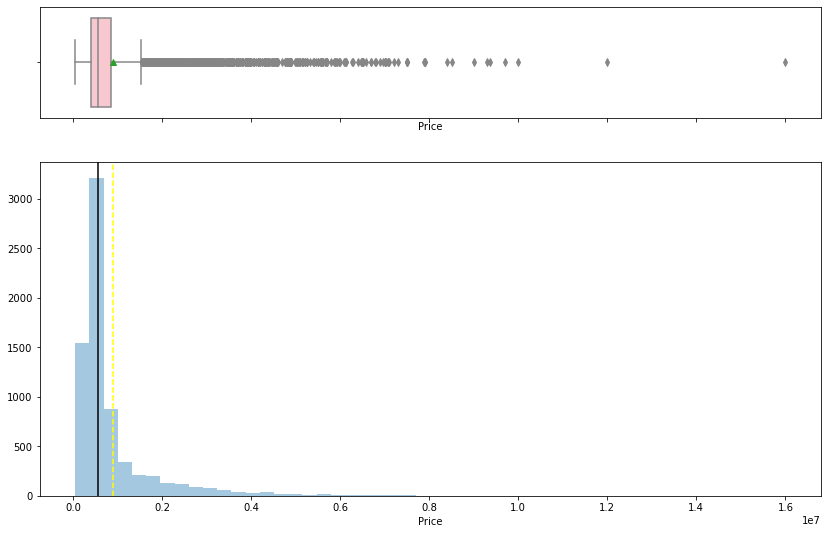

```python
histogram_boxplot(c_d["Price"])
plt.savefig('Plot_Price.png')
plt.show()
```

### Observation

```
1. There are massive outliers.This may be accounted for by erroneous data colection or variablity in methods
2. Price distribution appear normal but heavily rightly skewed with Mean (886,664) and Median (564,000)
3. 50% of potential sales topped 564,000 and below  while 75% of potential revenue was below 850,000
4. We will further treat the skewness using Log Transformation
```

#### Investigating Price Further and trying to minimise/correct skewness due to heavy outlier presence

### Price LogTransformation

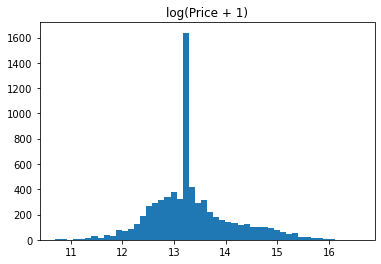

```python
plt.hist(np.log(c_d['Price'] + 1), 50)
plt.title('log(Price + 1)')
plt.savefig('Plt_pLogt')
plt.show()
```

#### Observation

1. Note that the skewness has greatly been eliminated to affirm a Normal Distribution
2. Price definitely behaves better on a Log scale

### Power Analysis

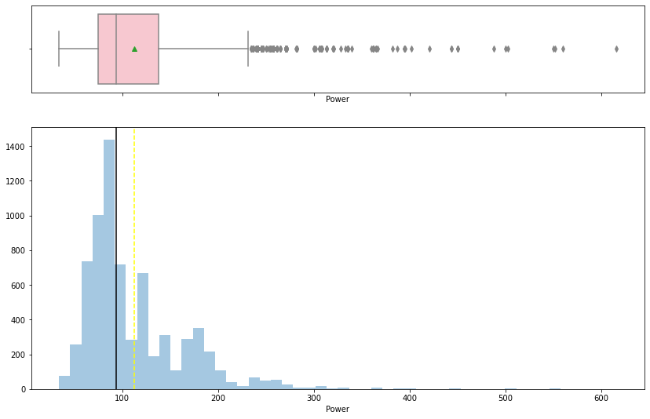

```python
histogram_boxplot(c_d["Power"])
plt.savefig('Plot_Pw.png')
plt.show()
```

### Mileage Analysis

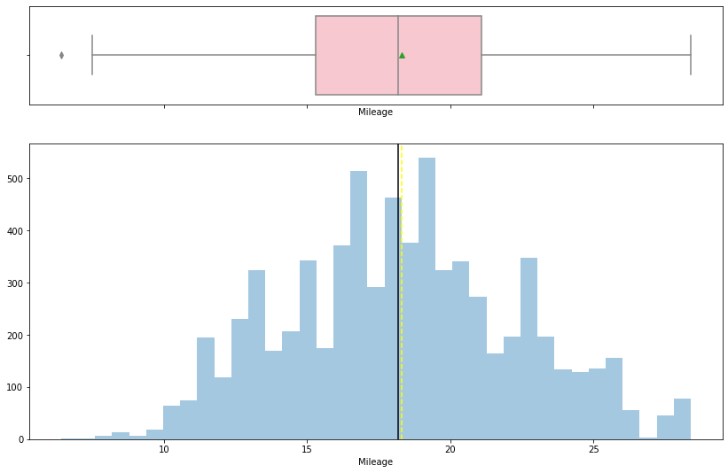

```python
histogram_boxplot(c_d["Mileage"])
plt.savefig('Plot_Ml.png')
plt.show()
```

### Engine Analysis

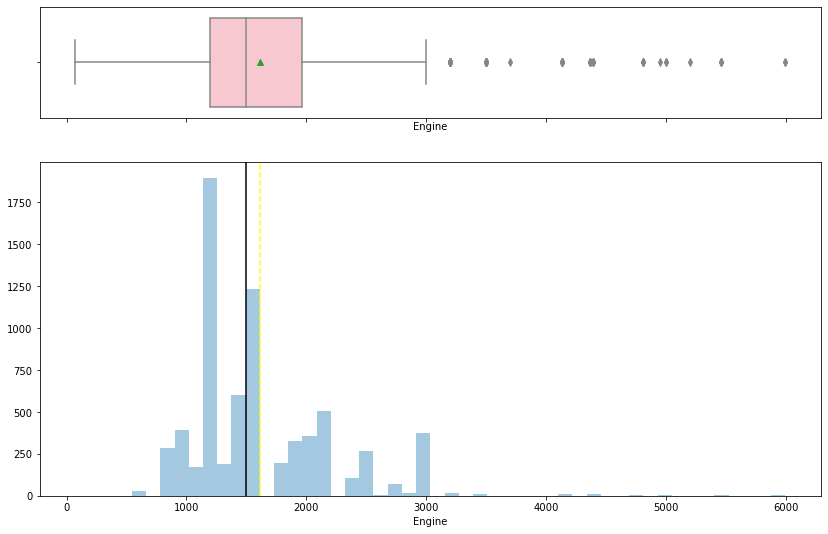

```python
histogram_boxplot(c_d["Engine"])
plt.savefig('Plot_E.png')
plt.show()
```

### KIlometers_Driven Analysis

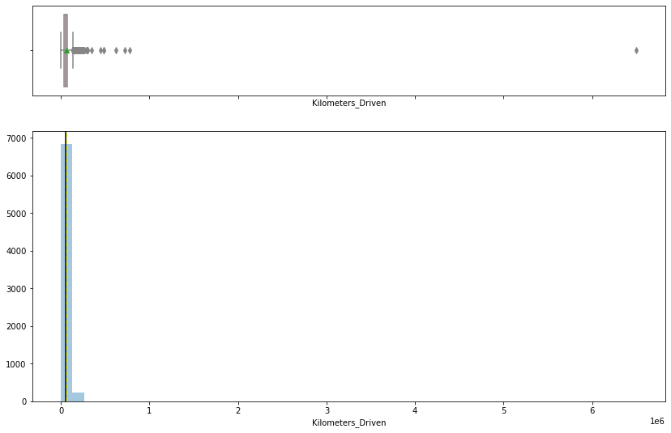

```python
histogram_boxplot(c_d["Kilometers_Driven"])
plt.savefig('Plot_KE.png')
plt.show()
```

### Observation

```
1. There are massive outliers.This may be accounted for by erroneous data colection or variablity in methods
2. Kilometer_Driven Distribution suggests a normal one but will be investigated with a LogTransformation
3. This is heavily rightly skewed as seen from the range(6499829) and standard deviation(85231)
4. 75% of the Used cars on sale covered a cummulative distance of under 72669 prior to sale
```

#### Log Transformation for Correction

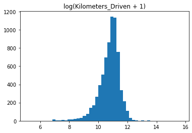

```python
plt.hist(np.log(c_d['Kilometers_Driven'] + 1), 50)
plt.title('log(Kilometers_Driven + 1)')
plt.savefig('Plt_kLogt')
plt.show()
```

#### Observation

The Power of Log Transformation and its effect on kurtosis. We can see an apparent Normal distribution

### Seats Analysis

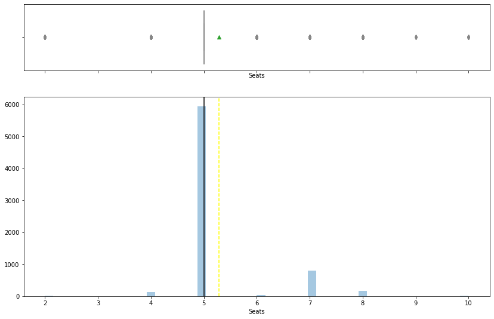

```python
histogram_boxplot(c_d["Seats"])
plt.savefig('Plot_Se.png')
plt.show()
```

### Analysis of Non-Numeric Variables

```python
# Prior to the commencement of analysis of non-numeric variables, we would need to split the 'Name' column into "Brand"
c_d['Name']= my_data['Name']
nm_splt = c_d['Name'].str.split(" ",expand = True)
c_d['Brand'] = nm_splt[0].str.strip().str.title() #This will be dropped prior to linear regression
c_d['Spec'] = nm_splt[1].str.strip().str.title() #This will be dropped prior to linear regression
c_d['Make'] = c_d[['Brand','Spec']].agg(''.join, axis=1) #This will be dropped prior to linear regression
c_d.drop(['Name'],axis=1, inplace = True)
c_d.head()
```

|  | Location | Year | Kilometers_Driven | Fuel_Type | Transmission | Owner_Type | Mileage | Engine | Power | Seats | Price | Brand | Spec | Make |
| --- | --- | --- | --- | --- | --- | --- | --- | --- | --- | --- | --- | --- | --- | --- |
| 0 | Mumbai | 2010 | 72000 | CNG | Manual | First | 18.150 | 998.000 | 58.160 | 5.000 | 175000.000 | Maruti | Wagon | MarutiWagon |
| 1 | Pune | 2015 | 41000 | Diesel | Manual | First | 19.670 | 1582.000 | 126.200 | 5.000 | 1250000.000 | Hyundai | Creta | HyundaiCreta |
| 2 | Chennai | 2011 | 46000 | Petrol | Manual | First | 18.200 | 1199.000 | 88.700 | 5.000 | 450000.000 | Honda | Jazz | HondaJazz |
| 3 | Chennai | 2012 | 87000 | Diesel | Manual | First | 20.770 | 1248.000 | 88.760 | 7.000 | 600000.000 | Maruti | Ertiga | MarutiErtiga |
| 4 | Coimbatore | 2013 | 40670 | Diesel | Automatic | Second | 15.200 | 1968.000 | 140.800 | 5.000 | 1774000.000 | Audi | A4 | AudiA4 |

```python
# We will now drop the Spec and Make colums for our Analysis
c_d.drop(['Spec','Make'], axis=1, inplace= True)
c_d.head()
```

|  | Location | Year | Kilometers_Driven | Fuel_Type | Transmission | Owner_Type | Mileage | Engine | Power | Seats | Price | Brand |
| --- | --- | --- | --- | --- | --- | --- | --- | --- | --- | --- | --- | --- |
| 0 | Mumbai | 2010 | 72000 | CNG | Manual | First | 18.150 | 998.000 | 58.160 | 5.000 | 175000.000 | Maruti |
| 1 | Pune | 2015 | 41000 | Diesel | Manual | First | 19.670 | 1582.000 | 126.200 | 5.000 | 1250000.000 | Hyundai |
| 2 | Chennai | 2011 | 46000 | Petrol | Manual | First | 18.200 | 1199.000 | 88.700 | 5.000 | 450000.000 | Honda |
| 3 | Chennai | 2012 | 87000 | Diesel | Manual | First | 20.770 | 1248.000 | 88.760 | 7.000 | 600000.000 | Maruti |
| 4 | Coimbatore | 2013 | 40670 | Diesel | Automatic | Second | 15.200 | 1968.000 | 140.800 | 5.000 | 1774000.000 | Audi |

```python
c_d['Brand']= c_d['Brand'].astype('category')
c_d.dtypes
```

```
Location             category
Year                 category
Kilometers_Driven       int64
Fuel_Type            category
Transmission         category
Owner_Type           category
Mileage               float64
Engine                float64
Power                 float64
Seats                 float64
Price                 float64
Brand                category
dtype: object
```

```python
# looking at value counts for non-numeric features

num_to_display = 10  # defining this up here so it's easy to change later if I want
for colname in c_d.dtypes[c_d.dtypes == 'category'].index:
    val_counts = c_d[colname].value_counts(dropna=False)  # i want to see NA counts
    print(val_counts[:num_to_display])
    if len(val_counts) > num_to_display:
        print(f'Only displaying first {num_to_display} of {len(val_counts)} values.')
    print('\n\n') # just for more space between
```

```
Mumbai        934
Hyderabad     846
Kochi         765
Coimbatore    758
Pune          738
Delhi         653
Kolkata       636
Chennai       571
Jaipur        487
Bangalore     422
Name: Location, dtype: int64
Only displaying first 10 of 11 values.



2015    925
2014    921
2016    878
2013    777
2017    709
2012    663
2011    566
2010    397
2018    360
2009    241
Name: Year, dtype: int64
Only displaying first 10 of 23 values.



Diesel      3771
Petrol      3230
CNG           61
LPG           12
Electric       2
Name: Fuel_Type, dtype: int64



Manual       5064
```

[output cut: 10 more lines]

```



Maruti           1417
Hyundai          1277
Honda             738
Toyota            485
Volkswagen        373
Mercedes-Benz     364
Ford              342
Mahindra          327
Bmw               312
Audi              283
Name: Brand, dtype: int64
Only displaying first 10 of 30 values.
```

```python
# Function to create barplots that indicate percentage for each category.

def perc_on_bar(plot, feature):
    '''
    plot
    feature: categorical feature
    the function won't work if a column is passed in hue parameter
    '''
    total = len(feature) # length of the column
    for p in ax.patches:
        percentage = '{:.1f}%'.format(100 * p.get_height()/total) # percentage of each class of the category
        x = p.get_x() + p.get_width() / 2 - 0.05 # width of the plot
        y = p.get_y() + p.get_height()           # height of the plot
        ax.annotate(percentage, (x, y), size = 14) # annotate the percantage
    plt.show() # show the plot
```

### Brand Analysis

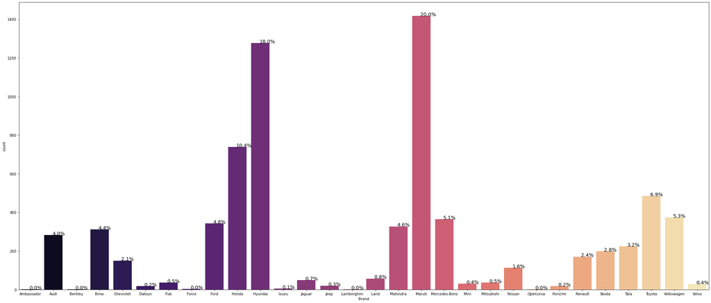

```python
plt.figure(figsize=(35,15))
ax = sns.countplot(c_d["Brand"],palette='magma');
perc_on_bar(ax,c_d["Brand"])
plt.savefig('Plot_Br.png')
```

### Location Analysis

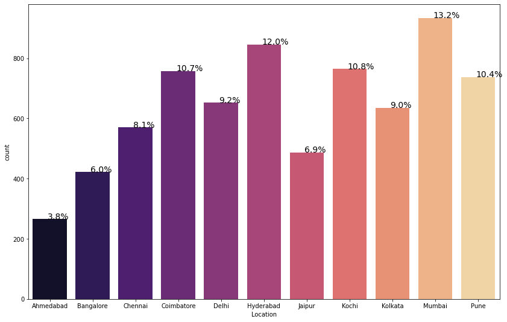

```python
plt.figure(figsize=(14,9))
ax = sns.countplot(c_d["Location"],palette='magma')
perc_on_bar(ax,c_d["Location"])
plt.savefig('Plot_Lc.png')
```

### Observation

1. Mumbai (13.2%), Hyderabad(12,0%) and Kochi(10.8%) respectively account for over one-third of units on sale accross the 11 different locations
2. The least in terms of units on sale is Ahmedabad

### Fuel Type Analysis

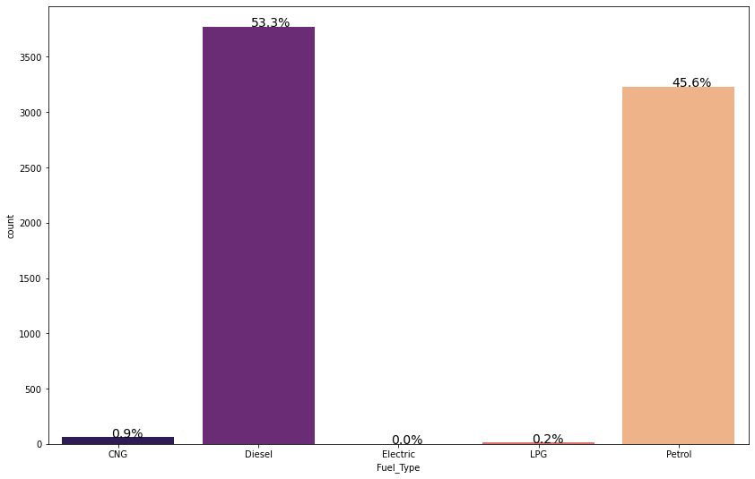

```python
plt.figure(figsize=(14,9))
ax = sns.countplot(c_d["Fuel_Type"],palette='magma');
perc_on_bar(ax,c_d["Fuel_Type"])
plt.savefig('Plot_Ft.png')
```

### Observation

1. Diesel used cars topped potential sales at 53.3% followed by Petrol
2. Clearly, stock for used cars of CNG, LPG and Electric fuel types are at a distant low

### Transmission Analysis

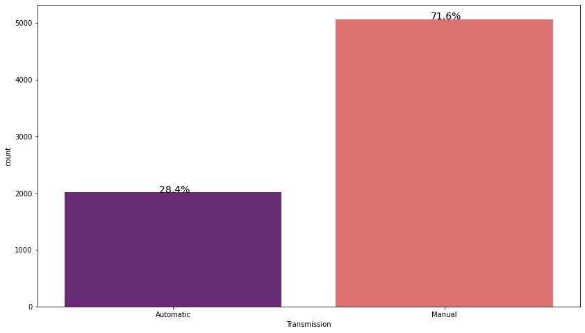

```python
plt.figure(figsize=(14,8))
ax = sns.countplot(c_d["Transmission"],palette='magma');
perc_on_bar(ax,c_d["Transmission"])
plt.savefig('Plot_T.png')
```

#### Observation

1. Used cars with Manual transmission is the most predominant amongst car dealers with a 71.6% inventory position
2. Automatic transmission has less attraction in the used car market with a 28.4% share due to it being priced higher

### Owner_Type Analysis

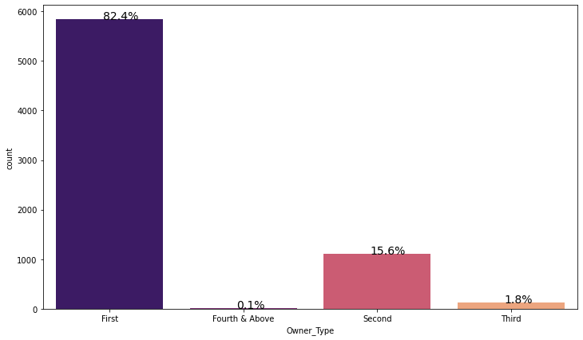

```python
plt.figure(figsize=(12,7))
ax = sns.countplot(c_d["Owner_Type"],palette='magma');
perc_on_bar(ax,c_d["Owner_Type"])
plt.savefig('Plot_OT.png')
```

#### Observation

1. Dealers preference for used cars by First owners trumped the rest by 82.4% followed by a distant 15.6% of Second Owner types.
2. There is a very low affinity for used cars by Third and fourth owners.

### Year Analysis

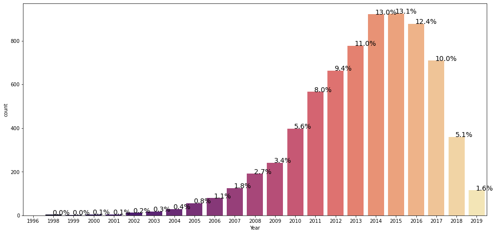

```python
plt.figure(figsize=(17,8))
ax = sns.countplot(c_d["Year"],palette='magma');
perc_on_bar(ax,c_d["Year"])
plt.savefig('Plot_Y.png')
```

#### Observation

1. 2015 ( 13.1%), 2014(13%), 2016(12.4%) and 2013(11.0%) models respectly account for close to 50% of potential sales indicating indicating preference for fairly used cars
2. Older models between 1998 to 2007 are less attractions

### Correlation Relationship

```python
# Since Price is the variable of interest which depends on other factors,
# we need to investigate relationship between Numericals and Non-Numericals as it affects Pricing

c_d[c_d.columns[:]].corr()['Price'][:] # We will look at data correlation by Price
```

```
Kilometers_Driven   -0.007
Mileage             -0.303
Engine               0.600
Power                0.706
Seats                0.052
Price                1.000
Name: Price, dtype: float64
```

### Observation

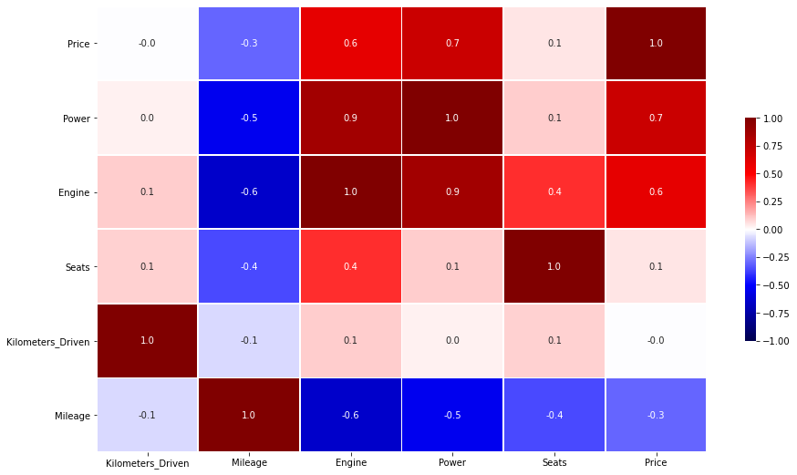

```python
numeric_columns = c_d.select_dtypes(include=np.number).columns.tolist()
corr = c_d[numeric_columns].corr().sort_values(by=['Price'],ascending=False) # sorting correlations w.r.t Price


# Set up the matplotlib figure
f, ax = plt.subplots(figsize=(15, 9))
plt.savefig('Plt_Htmap.png')

# Draw the heatmap with the mask and correct aspect ratio
sns.heatmap(corr, cmap='seismic', annot=True, fmt=".1f", vmin=-1, vmax=1, center= 0,
            square=False, linewidths=.7, cbar_kws={"shrink": .5});
```

### Obseravtions

1. As earlier observed,Price is highly correlated with Engine and Power
2. Engine is highly correlated with Power as well but inversely proportional to Mileage
3. There is very little or no correlation between Price the rest.

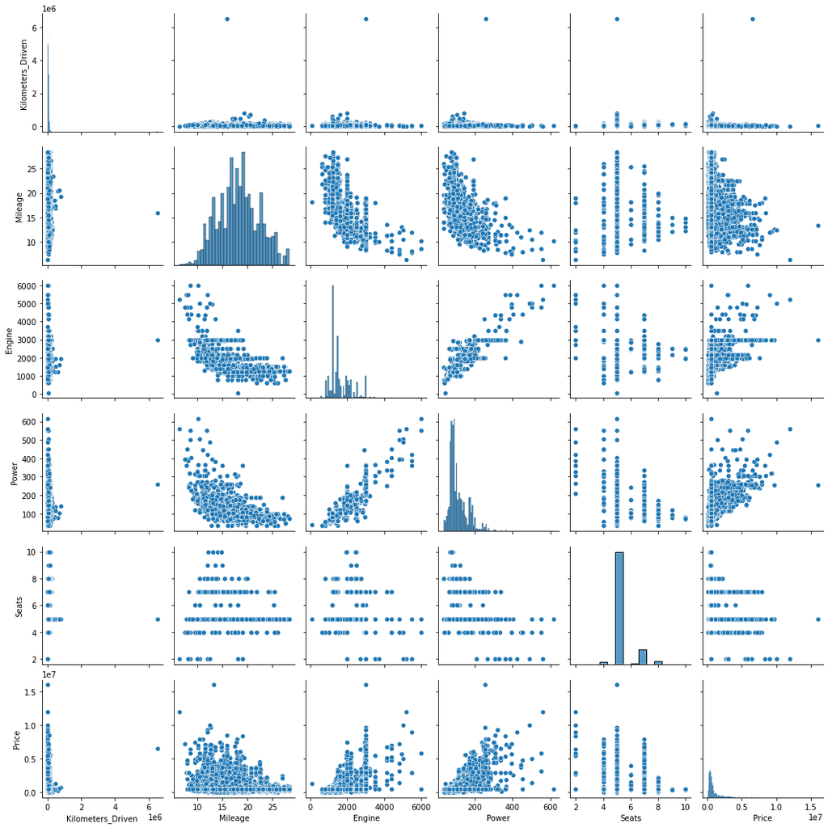

```python
sns.pairplot(c_d); # pair plot for all numerical variables
plt.savefig('Pair_plt.png')
plt.show()
```

### Bivariate Visualisations by Price

### Price Vs Engine Vs Fuel_Type

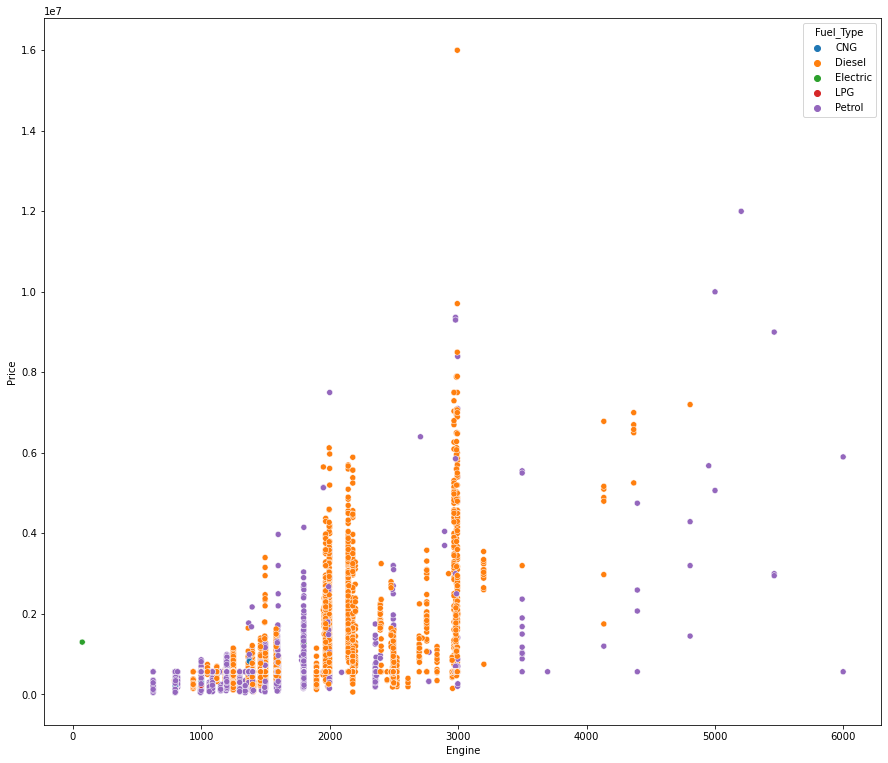

```python
# Lets look visualize the relationship
plt.figure(figsize=(15,13))
sns.scatterplot(y='Price', x='Engine', hue='Fuel_Type', data=c_d);
plt.savefig('Plot_PEF.png')
```

### Observations

1. The higher the Engine capacity,the more robust the fuel type (Diesel) and thus the higher the Price
2. The point dispersion especially for the Petrol accounts for a chunk of the outliers seen

### Price Vs Mileage Vs Brand

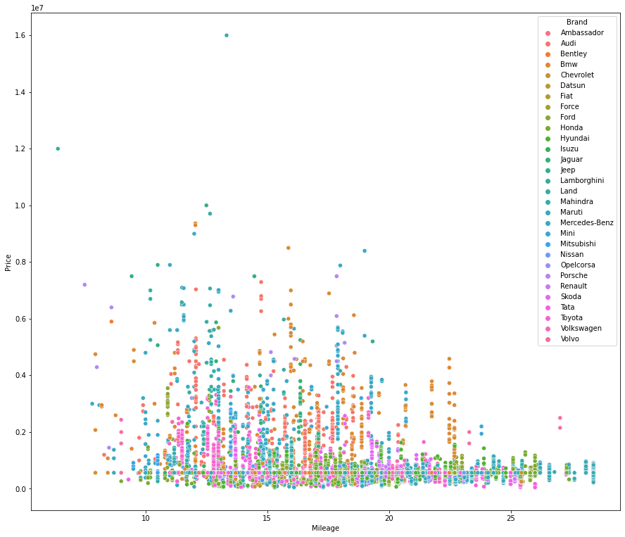

```python
plt.figure(figsize=(15,13))
sns.scatterplot(y='Price', x='Mileage', hue='Brand', data=c_d);
plt.savefig('Plot_PMB.png')
```

### Price Vs Kilometers_Driven Vs Year

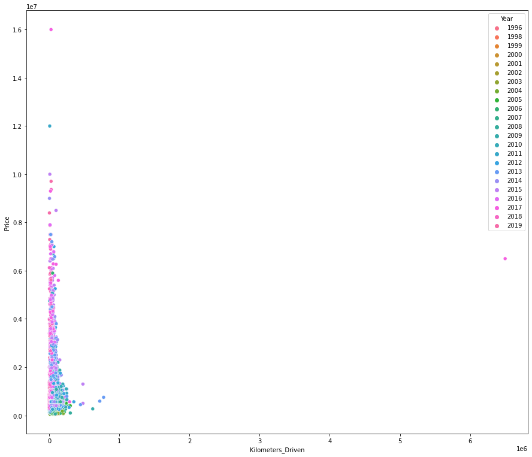

```python
plt.figure(figsize=(15,13))
sns.scatterplot(y='Price', x='Kilometers_Driven', hue='Year', data=c_d);
plt.savefig('Plot_PKY.png')
```

### Observation

1. We can see that the Kilometers_Driven has an adverse impact on Price.
2. Used car models of year 2015 with less Kilometers covered prior to sale had the most preference

### Price Vs Power Vs Location

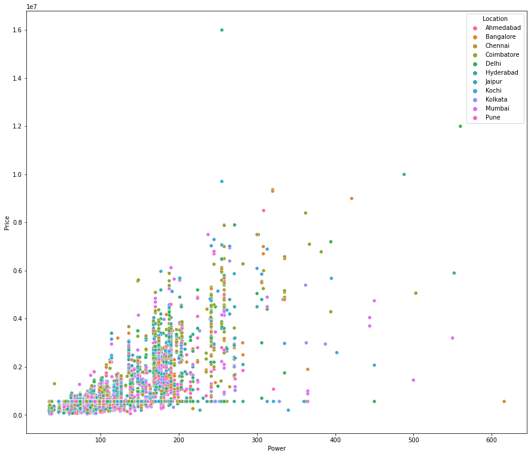

```python
plt.figure(figsize=(15,13))
sns.scatterplot(y='Price', x='Power', hue='Location', data=c_d);
plt.savefig('Plot_PPL.png')
```

### Observation

1. The obvious linearity between Price and Power is unquestionable
2. The frequency of data points representing Mumbai reflects an unmatched inventory of used car units on sale

## Price Vs Location

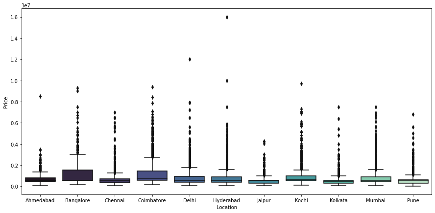

```python
plt.figure(figsize=(15,7))
sns.boxplot(c_d["Location"],c_d["Price"],palette="mako")
plt.savefig('Plot_PL.png')
plt.show()
```

### Observation

1. The city of Bangalore accounts for the most priced cars in India followed by Coimbatore
2. Interestingly, Mumbai with the highest inventory of cars, have relatively averagely priced cars on sale
3. The cities of Delhi,Kochi and Hyderabad return regular price regimes for used cars in stock

### Price Vs Owner Type

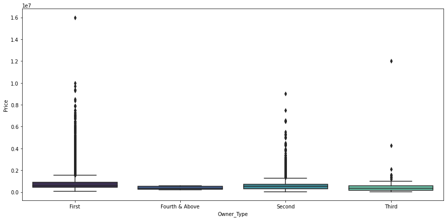

```python
plt.figure(figsize=(15,7))
sns.boxplot(c_d["Owner_Type"],c_d["Price"],palette="mako")
plt.savefig('Plot_PO.png')
plt.show()
```

### Observation

1. We can see the Owner_Type determiines the Pricing as the First Owner_Types are most sought after followed by the second
2. Pressure from a lot of Outliers

### Price Vs Transmission

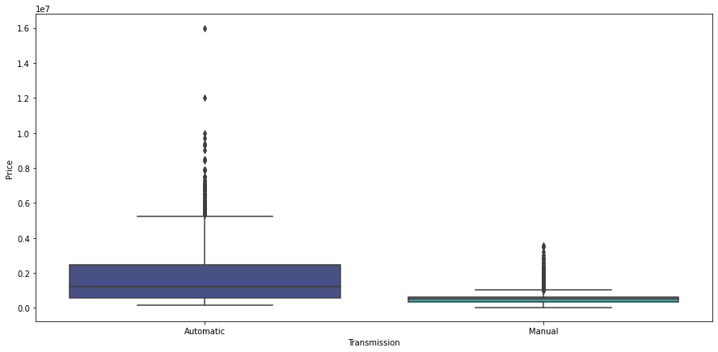

```python
plt.figure(figsize=(15,7))
sns.boxplot(c_d["Transmission"],c_d["Price"],palette="mako")
plt.savefig('Plot_TP.png')
plt.show()
```

### Observation

1. Transmission is a reliable estimator of Price as can be seen from the plot
2. Automatic Transmission sold higher than the Manual

### Price Vs Fuel_Type

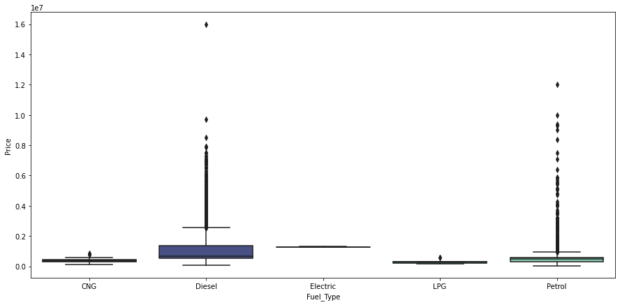

```python
plt.figure(figsize=(15,7))
sns.boxplot(c_d["Fuel_Type"],c_d["Price"],palette="mako")
plt.savefig('Plot_PF.png')
plt.show()
```

### Price vs Fuel_Type vs Owner Type

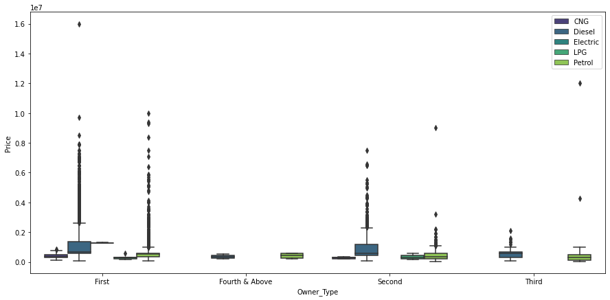

```python
plt.figure(figsize=(15,7))
sns.boxplot(c_d["Owner_Type"],c_d["Price"],hue=c_d["Fuel_Type"],palette="viridis")
plt.legend(bbox_to_anchor=(1.00, 1))
plt.savefig('Boxplt_ptt.png')
plt.show()
```

### Observation

1. Right away, it is apparent used cars driven by first owners with Diesel fuel types are higher priced followed by second owner types
2. Also amongst first owner types, diesel fuel types are preferred compared to Petrol hence are priced higher
3. Interestingly, petrol is prefered by buyers of fourth owner types and are priced almost at par with Petrol of second owner types

### Prive Vs Seats Vs Transmission

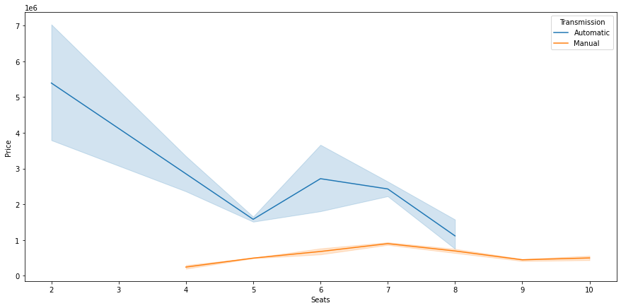

```python
plt.figure(figsize=(15,7))
sns.lineplot(x='Seats', y='Price',hue='Transmission', data= c_d);
plt.savefig('lineplt_PST')
plt.show()
```

### Observation

1. Used cars with Automatics transmission decreased in price with an increase in the number of seats with a trough at 5
2. This pattern clearly speaks to luxury models with automatic transmission like Coupes and SuVs
3. We can also see a pattern of gradual increase in the number of seats fom 5, peaked at 6 and then down to 7.
4. This speaks to Caravans and Family vehicles with Automatic transmissions likey
5. Manual used cars are priced quite low as the number of seats increase

## Data PreProcessing

#### Fix Data Type

##### This has been fixed already even though we sill be dropping some columns that doo not have any impact on the Target variable

```python
c_d.dtypes
```

```
Location             category
Year                 category
Kilometers_Driven       int64
Fuel_Type            category
Transmission         category
Owner_Type           category
Mileage               float64
Engine                float64
Power                 float64
Seats                 float64
Price                 float64
Brand                category
dtype: object
```

## Outlier Treatment

```python
# Lets treat outliers by flooring and capping
def treat_outliers(c_d,col):
    '''
    treats outliers in a varaible
    col: str, name of the numerical varaible
    c_d: data frame
    col: name of the column
    '''
    Q1=c_d[col].quantile(0.25) # 25th quantile
    Q3=c_d[col].quantile(0.75)  # 75th quantile
    IQR=Q3-Q1
    Lower_Whisker = Q1 - 1.5*IQR
    Upper_Whisker = Q3 + 1.5*IQR
    c_d[col] = np.clip(c_d[col], Lower_Whisker, Upper_Whisker) # all the values samller than Lower_Whisker will be assigned value of Lower_whisker
                                                            # and all the values above upper_whishker will be assigned value of upper_Whisker
    return c_d

def treat_outliers_all(c_d, col_list):
    '''
    treat outlier in all numerical varaibles
    col_list: list of numerical varaibles
    df: data frame
    '''
    for c in col_list:
        c_d = treat_outliers(c_d,c)

    return c_d
```

### Treatment

```python
num_cols = c_d.select_dtypes(include=np.number).columns.tolist()
c_d = treat_outliers_all(c_d,num_cols)
```

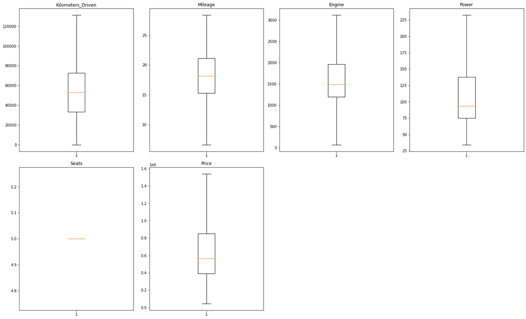

```python
# lets look at box plot to see if outliers has been treated or not
plt.figure(figsize=(20,30))

for i, variable in enumerate(num_cols):
                     plt.subplot(5,4,i+1)
                     plt.boxplot(c_d[variable],whis=1.5)
                     plt.tight_layout()
                     plt.title(variable)

plt.savefig('Outlier.png')
plt.show()
```

#### Outliers have been treated

### Feature Engingeering: Preparing Data for Model Integrity

```python
# I will be creating a new column that will give me the Age of each vehicle so that I can drop Year prior
# Also, I will be dropping the Location subsequently as its impact is secondary if not neglibile on Price
Present_Year = 2021
c_d['Year']=c_d['Year'].astype('float64')
c_d['Age']= Present_Year-c_d['Year']# Creating a column for Age of used cars
c_d.head(1)
```

|  | Location | Year | Kilometers_Driven | Fuel_Type | Transmission | Owner_Type | Mileage | Engine | Power | Seats | Price | Brand | Age |
| --- | --- | --- | --- | --- | --- | --- | --- | --- | --- | --- | --- | --- | --- |
| 0 | Mumbai | 2010.000 | 72000.000 | CNG | Manual | First | 18.150 | 998.000 | 58.160 | 5.000 | 175000.000 | Maruti | 11.000 |

```python
c_d.Age.dtype
```

```
dtype('float64')
```

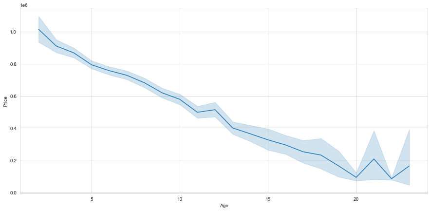

```python
plt.figure(figsize=(15,7))
sns.lineplot(x='Age', y='Price',data= c_d);
plt.savefig('lineplt_PA')
plt.show()
```

### Observation

1. We can clearly infer from the plot that there is an inverse relation between Price and Age
2. This implies that a unit increase in the Age of a used vehicle leads to a decrease in the Price of that vehicle.

## Model Building

```python
#Defining X and y variables
X = c_d.drop(['Price','Brand','Year'], axis=1)
y = c_d[['Price']]/100000 # Taking Price back to Lakh

print(X.head())
print(y.head())
```

```
     Location  Kilometers_Driven Fuel_Type Transmission Owner_Type  Mileage  \
0      Mumbai          72000.000       CNG       Manual      First   18.150
1        Pune          41000.000    Diesel       Manual      First   19.670
2     Chennai          46000.000    Petrol       Manual      First   18.200
3     Chennai          87000.000    Diesel       Manual      First   20.770
4  Coimbatore          40670.000    Diesel    Automatic     Second   15.200

    Engine   Power  Seats    Age
0  998.000  58.160  5.000 11.000
1 1582.000 126.200  5.000  6.000
2 1199.000  88.700  5.000 10.000
3 1248.000  88.760  5.000  9.000
4 1968.000 140.800  5.000  8.000
   Price
0  1.750
1 12.500
2  4.500
3  6.000
4 15.400
```

```python
print(X.shape)
print(y.shape)
```

```
(7076, 10)
(7076, 1)
```

## Creating Dummy Variables

```python
X = pd.get_dummies(X, columns=['Location', 'Transmission','Owner_Type','Fuel_Type'], drop_first=True)
X.head()
```

|  | Kilometers_Driven | Mileage | Engine | Power | Seats | Age | Location_Bangalore | Location_Chennai | Location_Coimbatore | Location_Delhi | ... | Location_Mumbai | Location_Pune | Transmission_Manual | Owner_Type_Fourth & Above | Owner_Type_Second | Owner_Type_Third | Fuel_Type_Diesel | Fuel_Type_Electric | Fuel_Type_LPG | Fuel_Type_Petrol |
| --- | --- | --- | --- | --- | --- | --- | --- | --- | --- | --- | --- | --- | --- | --- | --- | --- | --- | --- | --- | --- | --- |
| 0 | 72000.000 | 18.150 | 998.000 | 58.160 | 5.000 | 11.000 | 0 | 0 | 0 | 0 | ... | 1 | 0 | 1 | 0 | 0 | 0 | 0 | 0 | 0 | 0 |
| 1 | 41000.000 | 19.670 | 1582.000 | 126.200 | 5.000 | 6.000 | 0 | 0 | 0 | 0 | ... | 0 | 1 | 1 | 0 | 0 | 0 | 1 | 0 | 0 | 0 |
| 2 | 46000.000 | 18.200 | 1199.000 | 88.700 | 5.000 | 10.000 | 0 | 1 | 0 | 0 | ... | 0 | 0 | 1 | 0 | 0 | 0 | 0 | 0 | 0 | 1 |
| 3 | 87000.000 | 20.770 | 1248.000 | 88.760 | 5.000 | 9.000 | 0 | 1 | 0 | 0 | ... | 0 | 0 | 1 | 0 | 0 | 0 | 1 | 0 | 0 | 0 |
| 4 | 40670.000 | 15.200 | 1968.000 | 140.800 | 5.000 | 8.000 | 0 | 0 | 1 | 0 | ... | 0 | 0 | 0 | 0 | 1 | 0 | 1 | 0 | 0 | 0 |

5 rows × 24 columns

```python
#split the data into train and test
from sklearn.model_selection import train_test_split
X_train1, X_test, y_train, y_test = train_test_split(X, y, test_size=0.3, random_state=42)
```

# Choose Model, Train and Evaluate

```python
###Fitting linear model

from sklearn.linear_model import LinearRegression
linearregression = LinearRegression()
linearregression.fit(X_train1, y_train)

print("Intercept of the linear equation:", linearregression.intercept_)
print("\nCoefficients of the equation are:", linearregression.coef_)

from sklearn.metrics import mean_absolute_error, mean_squared_error, r2_score

pred = linearregression.predict(X_test)
```

```
Intercept of the linear equation: [6.95032852]

Coefficients of the equation are: [[-1.08529883e-05 -8.90775609e-02  6.52182844e-04  4.04747927e-02
  -2.16493490e-15 -4.06787277e-01  3.76559548e-01  6.19071496e-02
   4.85393181e-01 -1.66903784e-01  4.72700158e-01 -1.15615089e-01
   2.13206474e-02 -8.97744100e-01 -2.10465944e-01  3.19717971e-02
  -1.32938565e+00  7.65819048e-01 -1.98012755e-01 -3.12470127e-01
   1.38047982e+00  8.25984949e+00  6.08687312e-01 -5.09810266e-02]]
```

## Model Performances

```python
### Mean Absolute Error on test
mean_absolute_error(y_test, pred)
```

```
1.6943823291434021
```

```python
### RMSE on test data
mean_squared_error(y_test, pred)**0.5
```

```
2.3376358428363084
```

```python
### R-squared on test
r2_score(y_test, pred)
```

```
0.6903634551551836
```

#### 𝑅-squared value is 0.69, which means that in this model,independent variables are able to explain 69% of the variance in the dependent variable.

```python
### Training Score

linearregression.score(X_train1, y_train)  # 70 % data
```

```
0.6972762112392935
```

```python
### Testing score

linearregression.score(X_test, y_test) # unseen data
```

```
0.6903634551551836
```

## Conclusion

##### The training and testing scores are 0.697% and 0.69%, and both scores are comparable. Hence, the model is a good fit.

##### 𝑅-squared is 0.69, that explains 69% of total variation in the dataset. So, overall the model is very satisfactory.

## Results from Statsmodels

This provides functions for the estimation of many statistical models, as well as for conducting statistical tests, and statistical data exploration

```python
# Lets us build linear regression model using statsmodel

X = sm.add_constant(X)
X_train1, X_test, y_train, y_test = train_test_split(X, y, test_size=0.3, random_state=42)

olsmod0 = sm.OLS(y_train, X_train1)
olsres0 = olsmod0.fit()
print(olsres0.summary())
```

```
                            OLS Regression Results
==============================================================================
Dep. Variable:                  Price   R-squared:                       0.697
Model:                            OLS   Adj. R-squared:                  0.696
Method:                 Least Squares   F-statistic:                     493.6
Date:                Sun, 16 May 2021   Prob (F-statistic):               0.00
Time:                        06:35:10   Log-Likelihood:                -11245.
No. Observations:                4953   AIC:                         2.254e+04
Df Residuals:                    4929   BIC:                         2.269e+04
Df Model:                          23
Covariance Type:            nonrobust
=============================================================================================
                                coef    std err          t      P>|t|      [0.025      0.975]
---------------------------------------------------------------------------------------------
Kilometers_Driven         -1.085e-05   1.54e-06     -7.063      0.000   -1.39e-05   -7.84e-06
Mileage                      -0.0891      0.015     -5.965      0.000      -0.118      -0.060
Engine                        0.0007      0.000      4.109      0.000       0.000       0.001
Power                         0.0405      0.002     24.131      0.000       0.037       0.044
Seats                         1.3901      0.118     11.810      0.000       1.159       1.621
Age                          -0.4068      0.015    -27.365      0.000      -0.436      -0.378
Location_Bangalore            0.3766      0.223      1.689      0.091      -0.060       0.814
Location_Chennai              0.0619      0.214      0.289      0.772      -0.358       0.482
Location_Coimbatore           0.4854      0.205      2.369      0.018       0.084       0.887
Location_Delhi               -0.1669      0.207     -0.806      0.420      -0.573       0.239
Location_Hyderabad            0.4727      0.201      2.355      0.019       0.079       0.866
Location_Jaipur              -0.1156      0.217     -0.532      0.595      -0.542       0.310
Location_Kochi                0.0213      0.205      0.104      0.917      -0.381       0.424
Location_Kolkata             -0.8977      0.210     -4.275      0.000      -1.309      -0.486
Location_Mumbai              -0.2105      0.200     -1.053      0.292      -0.602       0.181
Location_Pune                 0.0320      0.207      0.155      0.877      -0.373       0.437
Transmission_Manual          -1.3294      0.104    -12.831      0.000      -1.533      -1.126
Owner_Type_Fourth & Above     0.7658      0.894      0.856      0.392      -0.987       2.519
Owner_Type_Second            -0.1980      0.101     -1.962      0.050      -0.396      -0.000
Owner_Type_Third             -0.3125      0.257     -1.215      0.224      -0.817       0.192
Fuel_Type_Diesel              1.3805      0.376      3.669      0.000       0.643       2.118
Fuel_Type_Electric            8.2598      1.704      4.847      0.000       4.919      11.601
Fuel_Type_LPG                 0.6087      0.798      0.762      0.446      -0.956       2.174
Fuel_Type_Petrol             -0.0510      0.365     -0.140      0.889      -0.766       0.664
==============================================================================
Omnibus:                      451.376   Durbin-Watson:                   1.983
Prob(Omnibus):                  0.000   Jarque-Bera (JB):             1316.977
Skew:                          -0.487   Prob(JB):                    1.05e-286
Kurtosis:                       5.330   Cond. No.                     3.24e+06
==============================================================================

Notes:
[1] Standard Errors assume that the covariance matrix of the errors is correctly specified.
[2] The condition number is large, 3.24e+06. This might indicate that there are
strong multicollinearity or other numerical problems.
```

### Observations

- Assuming a confidence level of 0.05 (5%), then any variable with p-values less than 0.05 would be considered significant.
- A negative coefficient implies Price deceases with their increase.
- A positive coefficient implies Price inceases with their increase.
- Multicollinearity affects the p values, we will treat multicollinearity per p values

## Interpreting the Regression Results:

     Ho : Independent feature is not significant

     Ha : Independent feature is that it is significant

Pr(>|t|) gives P-value for each independent feature to check that null hypothesis. we are considering 0.05 (5%) as significance level

- A p-value of less than 0.05 is considered to be statistically significant.
  1. Confidence Interval: It represents the range in which our coefficients are likely to fall (with a likelihood of 95%).

### Testing the Linear Regression Assumptions

1. No Multicollinearity
2. Mean of residuals should be 0
3. No Heteroscedacity
4. Linearity of variables
5. Normality of error terms

### MULTICOLLINEARITY TEST

```python
## We will check Multicollinearity using VIF scores (VARIANCE INFLATION FACTORS)
## The VIF measures Variance Inflation of regression parameters due to correlation between predictors
## VIF =1 (No Correlation), VIF>5 (Moderate Correlation), VIF > 10 ( High Correlation)
from statsmodels.stats.outliers_influence import variance_inflation_factor

vif_series1 = pd.Series([variance_inflation_factor(X.values,i) for i in range(X.shape[1])],index=X.columns)
print('Series before feature selection: \n\n{}\n'.format(vif_series1))
```

```
Series before feature selection:

Kilometers_Driven             1.849
Mileage                       3.310
Engine                        7.240
Power                         5.453
Seats                       310.459
Age                           1.951
Location_Bangalore            2.463
Location_Chennai              2.941
Location_Coimbatore           3.524
Location_Delhi                3.150
Location_Hyderabad            3.717
Location_Jaipur               2.673
Location_Kochi                3.539
Location_Kolkata              3.132
Location_Mumbai               3.979
Location_Pune                 3.440
Transmission_Manual           1.948
Owner_Type_Fourth & Above     1.010
Owner_Type_Second             1.167
Owner_Type_Third              1.097
Fuel_Type_Diesel             31.874
Fuel_Type_Electric            1.037
Fuel_Type_LPG                 1.205
Fuel_Type_Petrol             29.821
dtype: float64
```

### Observation

As seen, many of the VIF scores are greater than 5.To remove Multicollinearity, the following steps are engaged,

1. Drop every column one by one, that has VIF score greater than 5.
2. Look at the adjusted R square of all these models
3. Drop the Variable that makes least change in Adjusted-R square
4. Check the VIF Scores again
5. Continue till you get all VIF scores under 5

```python
### we drop the one with the highest vif values and check the Adjusted-R Squared
X_train2 = X_train1.drop('Seats', axis=1)

vif_series2 = pd.Series([variance_inflation_factor(X_train2.values,i) for i in range(X_train2.shape[1])],index=X_train2.columns)
print('Series before feature selection: \n\n{}\n'.format(vif_series2))
```

```
Series before feature selection:

Kilometers_Driven            8.427
Mileage                     37.565
Engine                      54.082
Power                       36.370
Age                         12.484
Location_Bangalore           2.540
Location_Chennai             3.035
Location_Coimbatore          3.761
Location_Delhi               3.363
Location_Hyderabad           4.201
Location_Jaipur              2.829
Location_Kochi               3.718
Location_Kolkata             3.354
Location_Mumbai              4.303
Location_Pune                3.538
Transmission_Manual          6.591
Owner_Type_Fourth & Above    1.014
Owner_Type_Second            1.366
Owner_Type_Third             1.127
Fuel_Type_Diesel            56.273
Fuel_Type_Electric           1.031
Fuel_Type_LPG                1.185
Fuel_Type_Petrol            37.724
dtype: float64
```

##### The VIF scores for the numerical variables increased inferring high correlation amongst variables.

```python
olsmod1 = sm.OLS(y_train, X_train2)
olsres1 = olsmod1.fit()
print(olsres1.summary())
```

```
                                 OLS Regression Results
=======================================================================================
Dep. Variable:                  Price   R-squared (uncentered):                   0.915
Model:                            OLS   Adj. R-squared (uncentered):              0.915
Method:                 Least Squares   F-statistic:                              2313.
Date:                Sun, 16 May 2021   Prob (F-statistic):                        0.00
Time:                        06:35:11   Log-Likelihood:                         -11314.
No. Observations:                4953   AIC:                                  2.267e+04
Df Residuals:                    4930   BIC:                                  2.282e+04
Df Model:                          23
Covariance Type:            nonrobust
=============================================================================================
                                coef    std err          t      P>|t|      [0.025      0.975]
---------------------------------------------------------------------------------------------
Kilometers_Driven         -9.597e-06   1.55e-06     -6.175      0.000   -1.26e-05   -6.55e-06
Mileage                       0.0313      0.011      2.828      0.005       0.010       0.053
Engine                        0.0014      0.000      9.899      0.000       0.001       0.002
Power                         0.0424      0.002     25.057      0.000       0.039       0.046
Age                          -0.3667      0.015    -24.989      0.000      -0.395      -0.338
Location_Bangalore            1.0214      0.219      4.661      0.000       0.592       1.451
Location_Chennai              0.6451      0.211      3.055      0.002       0.231       1.059
Location_Coimbatore           1.2028      0.198      6.063      0.000       0.814       1.592
Location_Delhi                0.4849      0.202      2.397      0.017       0.088       0.882
Location_Hyderabad            1.0615      0.197      5.384      0.000       0.675       1.448
Location_Jaipur               0.4884      0.214      2.281      0.023       0.069       0.908
Location_Kochi                0.7338      0.199      3.686      0.000       0.343       1.124
Location_Kolkata             -0.3051      0.207     -1.476      0.140      -0.710       0.100
Location_Mumbai               0.4792      0.194      2.473      0.013       0.099       0.859
Location_Pune                 0.6714      0.202      3.318      0.001       0.275       1.068
Transmission_Manual          -1.0859      0.103    -10.547      0.000      -1.288      -0.884
Owner_Type_Fourth & Above     0.7573      0.907      0.835      0.404      -1.020       2.535
Owner_Type_Second            -0.2079      0.102     -2.032      0.042      -0.408      -0.007
Owner_Type_Third             -0.3933      0.261     -1.509      0.131      -0.904       0.118
Fuel_Type_Diesel              3.2229      0.347      9.283      0.000       2.542       3.904
Fuel_Type_Electric           11.1786      1.710      6.539      0.000       7.827      14.530
Fuel_Type_LPG                 3.0542      0.782      3.907      0.000       1.522       4.587
Fuel_Type_Petrol              2.3246      0.308      7.537      0.000       1.720       2.929
==============================================================================
Omnibus:                      416.001   Durbin-Watson:                   1.985
Prob(Omnibus):                  0.000   Jarque-Bera (JB):             1235.757
Skew:                          -0.441   Prob(JB):                    4.56e-269
Kurtosis:                       5.282   Cond. No.                     3.20e+06
==============================================================================

Notes:
[1] R² is computed without centering (uncentered) since the model does not contain a constant.
[2] Standard Errors assume that the covariance matrix of the errors is correctly specified.
[3] The condition number is large, 3.2e+06. This might indicate that there are
strong multicollinearity or other numerical problems.
```

```python
X_train3 = X_train2.drop('Mileage', axis=1)

vif_series3 = pd.Series([variance_inflation_factor(X_train3.values,i) for i in range(X_train3.shape[1])],index=X_train3.columns)
print('Series before feature selection: \n\n{}\n'.format(vif_series3))
```

```
Series before feature selection:

Kilometers_Driven            8.413
Engine                      43.059
Power                       35.907
Age                         12.382
Location_Bangalore           2.455
Location_Chennai             2.907
Location_Coimbatore          3.614
Location_Delhi               3.194
Location_Hyderabad           3.991
Location_Jaipur              2.717
Location_Kochi               3.515
Location_Kolkata             3.209
Location_Mumbai              4.078
Location_Pune                3.363
Transmission_Manual          6.213
Owner_Type_Fourth & Above    1.014
Owner_Type_Second            1.364
Owner_Type_Third             1.125
Fuel_Type_Diesel            24.212
Fuel_Type_Electric           1.013
Fuel_Type_LPG                1.100
Fuel_Type_Petrol            18.708
dtype: float64
```

```python
olsmod2 = sm.OLS(y_train, X_train3)
olsres2 = olsmod2.fit()
print(olsres2.summary())
```

```
                                 OLS Regression Results
=======================================================================================
Dep. Variable:                  Price   R-squared (uncentered):                   0.915
Model:                            OLS   Adj. R-squared (uncentered):              0.915
Method:                 Least Squares   F-statistic:                              2414.
Date:                Sun, 16 May 2021   Prob (F-statistic):                        0.00
Time:                        06:35:12   Log-Likelihood:                         -11318.
No. Observations:                4953   AIC:                                  2.268e+04
Df Residuals:                    4931   BIC:                                  2.282e+04
Df Model:                          22
Covariance Type:            nonrobust
=============================================================================================
                                coef    std err          t      P>|t|      [0.025      0.975]
---------------------------------------------------------------------------------------------
Kilometers_Driven         -9.771e-06   1.55e-06     -6.287      0.000   -1.28e-05   -6.72e-06
Engine                        0.0013      0.000      9.657      0.000       0.001       0.002
Power                         0.0430      0.002     25.521      0.000       0.040       0.046
Age                          -0.3704      0.015    -25.330      0.000      -0.399      -0.342
Location_Bangalore            1.1350      0.216      5.264      0.000       0.712       1.558
Location_Chennai              0.7674      0.207      3.710      0.000       0.362       1.173
Location_Coimbatore           1.3138      0.195      6.751      0.000       0.932       1.695
Location_Delhi                0.6131      0.197      3.107      0.002       0.226       1.000
Location_Hyderabad            1.1859      0.192      6.167      0.000       0.809       1.563
Location_Jaipur               0.6087      0.210      2.899      0.004       0.197       1.020
Location_Kochi                0.8655      0.194      4.468      0.000       0.486       1.245
Location_Kolkata             -0.1838      0.202     -0.908      0.364      -0.581       0.213
Location_Mumbai               0.6043      0.189      3.201      0.001       0.234       0.974
Location_Pune                 0.7986      0.197      4.045      0.000       0.412       1.186
Transmission_Manual          -1.0162      0.100    -10.159      0.000      -1.212      -0.820
Owner_Type_Fourth & Above     0.7023      0.907      0.774      0.439      -1.076       2.481
Owner_Type_Second            -0.2163      0.102     -2.114      0.035      -0.417      -0.016
Owner_Type_Third             -0.4182      0.261     -1.604      0.109      -0.929       0.093
Fuel_Type_Diesel              3.9639      0.228     17.394      0.000       3.517       4.411
Fuel_Type_Electric           11.8025      1.696      6.957      0.000       8.477      15.128
Fuel_Type_LPG                 3.6477      0.754      4.841      0.000       2.170       5.125
Fuel_Type_Petrol              2.9438      0.217     13.543      0.000       2.518       3.370
==============================================================================
Omnibus:                      416.965   Durbin-Watson:                   1.988
Prob(Omnibus):                  0.000   Jarque-Bera (JB):             1231.352
Skew:                          -0.444   Prob(JB):                    4.12e-268
Kurtosis:                       5.275   Cond. No.                     3.17e+06
==============================================================================

Notes:
[1] R² is computed without centering (uncentered) since the model does not contain a constant.
[2] Standard Errors assume that the covariance matrix of the errors is correctly specified.
[3] The condition number is large, 3.17e+06. This might indicate that there are
strong multicollinearity or other numerical problems.
```